# How to Build a Time Machine (with Git)

Paul Wang

2024 July

# Setting the Scene

- Today’s talk is **not** about specific commands / code.
- I want to talk about some of Git’s design decision, and from there talk about how we could take advantage of it.
- We will start with a scenario, then things will get visual and technical.

# A Typical Pickle

- Ross was working on a new feature for his project.
- He was 42% done when
  - His boss, Joey, sent him a message on Teams.
  - There was an urgent bug in the production code that needs fixing now.
- Ross needs to switch gear to patch the bug but
  - He doesn’t want to give up his *WIP* feature. However, the feature code is not in a working state.
- What to do?

# No Version Control

- Perhaps Ross copied the files before starting working on the new feature.
  - Save the feature works into a “feature” copy.
  - Find the newest clean copy (without the feature but one that contains the bug).
  - Make another copy, “bug_fix”, of it.
  - Patch the bug.
  - Email everyone about the fix, and where to get the latest bug-free copy.
  - Go back to the “feature” copy.
  - Try to manually merge the WIP feature implementation onto the “bug_fix” copy.
- Perhaps he didn’t make a copy
  - Pain

# No Version Control

- There are quite a few pitfalls with this approach:
1. **No backup**: If there wasn’t a copy with the desired state, you’re left with nothing but a bunch of useless files.
2. **Time-consuming**: This method is slow and laborious, especially when dealing with large file systems.
3. **Error-prone**: It’s easy to overwrite the wrong file or lose important changes due to manual mistakes.
4. **Difficult merges**: Ensuring that copies merge cleanly is a tedious process prone to errors.
5. **Collaboration nightmare**: Coordinating works between multiple developers or taking over from someone else is impossible with this approach.
6. **Forgetfulness**: After a few months, it’s nearly impossible to remember the intricacies of the process and what changes were made.

# What is Version Control System?

- What Ross needs is something that helps him to go back in the history, diverge it, and merge it with his original timeline.
- A VCS is like a time machine for your code. It lets you travel back in time, and try different parallel timelines.
- It allows code archaeology (how was the bug introduced? / how was it fixed? / how has this function evolved? / … ).
- More complex workflows are built upon it (collaboration, permission, code review, and releasing).

# What makes Git a Unique VCS?

- Git is the most popular VCS. It has > 95% market share.
- It was first developed in 2005 for maintaining one of the largest open-source projects: the Linux Kernel.
  - Emailing all patches to one guy to merge -> Burnout -> Proprietary VCS Software -> Someone tried to reverse-engineer it -> No more free licenses -> “I will write my own VCS”

```
"Now, I’m dealing with the fall-out, and I’ll write my own kernel source tracking tool because I can’t use the best any more. That’s OK - I deal with my own problems, thank you very much." - Linus Torvalds
```

- Its design emphasizes:
  - **Efficiency**: Able to handle large projects, which has can has millions lines of code and thousands of collaborators.
  - **Strong support for non-linear development**: thousands of parallel branches.
  - Data Integrity: once added, hard to lose; everything is checksum-ed.
  - Distributed: every local copy is a fully copy; most actions can be done without Internet.

# Time Machine from Scratch

- Now let’s try to understand Git.
- We will start from the basic - how Git see our files.
- Git sees every file in one of four states:
  1. untracked (“outside of the room”)
  2. modified (“chaotic gathering in the room”)
  3. staged (“people posing for a photo; adjusting frame”)
  4. **committed (“the photo taken”)** ← objective of the other steps

Eventually, we want to put things we care about into the committed state.

```
Quiz: Why do we need a staging area? Why not just "save"?
```

# What is a Commit?

- Every time you commit, Git takes a picture of what all your files look like at that moment and stores a reference to that snapshot (so that it can be retrieved).

- If the file didn’t change, Git points the reference at the previous version.
- For files that changed, Git will prefer storing the whole file again not just the difference*.

**Delta is space-friendly; full file is speed-friendly.** Git wants to make recreating the snapshot data fast.

# What is actually inside a commit?

Here is how a single commit looks like inside:

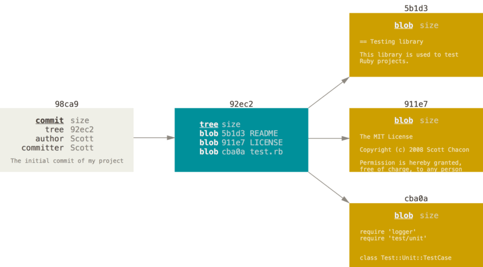

And here is what happens if we made another one:

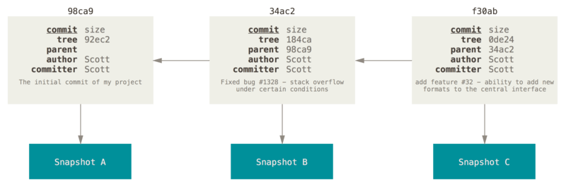

```
Quiz: How many parents can a commit have?
```

Another way to look at it together:

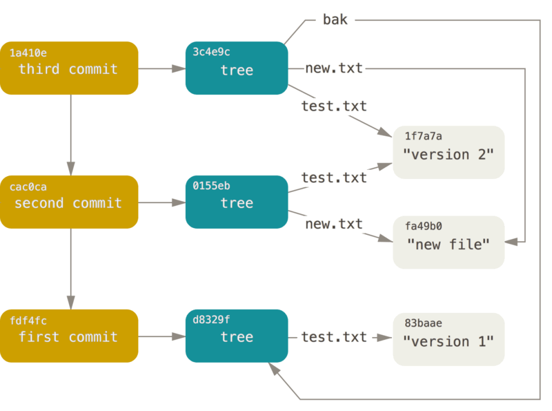

As we mentioned, duplicated data is not duplicatly stored, but referenced. Non-duplicated data is stored fully.

When we check out a commit, Git use the tree to find all data, decompressed them, and use that to populate our folder.

Notice how:

1. A commit has **snapshot**: a full map to find all the correct pieces of data!
2. A commit has **context**: author, timestamp, and commit message (who, when and why?)
3. A commit has **history**: always points to its parents; knows what comes before.

# What is a Branch?

So commit is contextual snapshot, and a chain of them forms a history.

How about multiple histories? Ross needs it.

This is where branches come in.

Branch is a movable pointer to a commit.

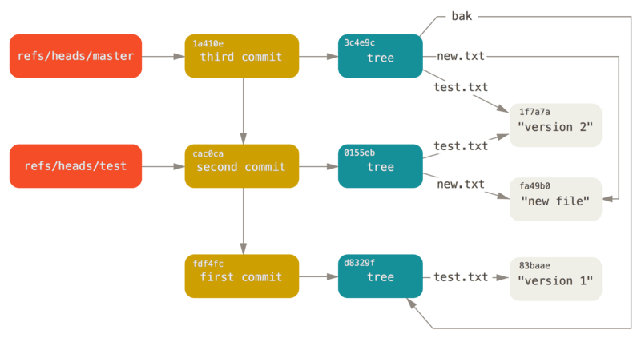

When a branch is created, Git just writes down “test is at cac0ca…”. It does not change the underlying files, copy files, compute, connect to Internet, whatever.

**Think of branching as making a bookmark, not copy-pasting.**

**Because of this, Git is optimized for fast and cheap branching**. People often create and delete multiple branches in a day, one for each topic they work on.

But how does Git know which branch you are on?

The answer is another pointer pointing to the branch pointer.

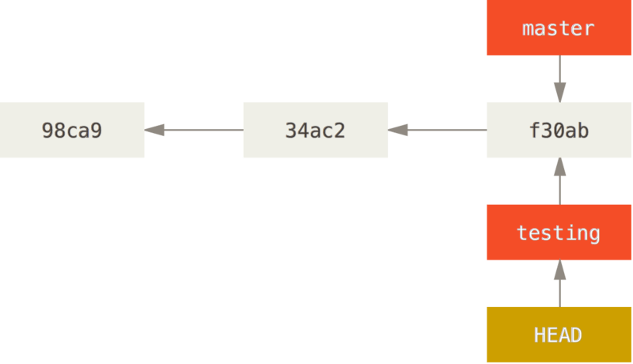

A special pointer, HEAD, marks the current branch.

Now if you make another commit

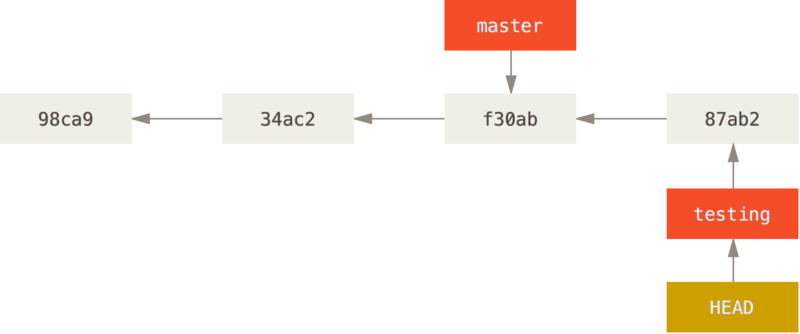

The pointer that HEAD points to, advanced, while the other pointer stays the same.

[figure not shown]

```
Quiz: You checked out a commit, Git says you are now in "detached HEAD state". What happened?!
```

This is it. Many actions in Git are just moving these pointers around.

For example:

- checkout/switch: move HEAD to point to another commit or branch
- reset: point current branch to an earlier commit.
- create a commit: take another snapshot that use current commit as a parent. Move the current branch to it.
- merge: try to create a commit that combine two parents. Move the current branch to it.

# Pickle Revisited

Now let’s go back to our earlier pickle example. Assuming Ross starts his work when there was a master branch, tracking prod.

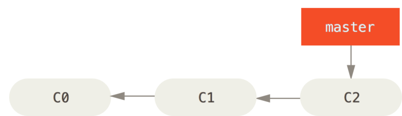

He creates a new branch (“iss53”) to track his feature works.

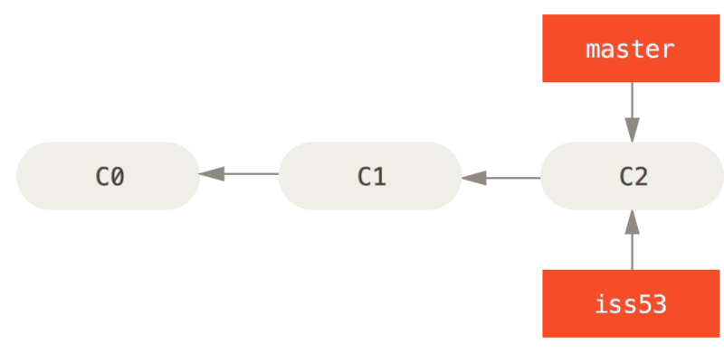

And do some works (C3) on that branch.

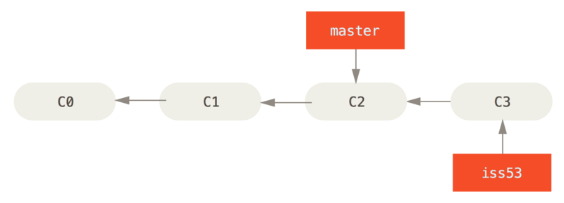

Now, if there is bug now, he can easily checkout “master”, create a “hotfix” branch and commit a fix (C4). His feature works are intact on “iss53”.

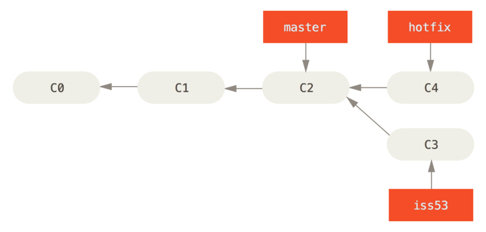

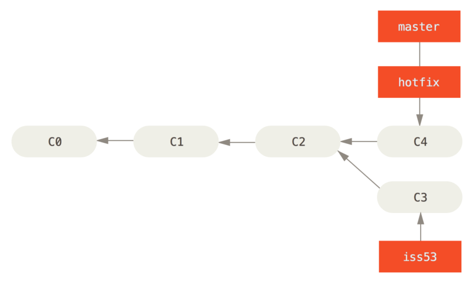

Now crisis averted Ross deletes the “hotfix” branch, and goes back to finish his feature (C5). After few days, it is ready to be integrated into master.

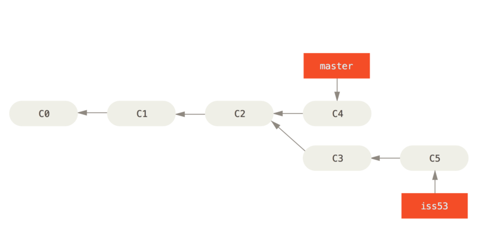

Since the history has diverged, “master” cannot reach “iss53” by fast-forward. The new commit will have two parents.

If each’s change relative to the ancestor (C2) is not overlapping (i.e. different files / lines), Git will merge them automatically. If it overlaps, then it is a conflict and Git will ask which side you want.

Most of time things merge cleanly automatically if the code is compartmentalized well.

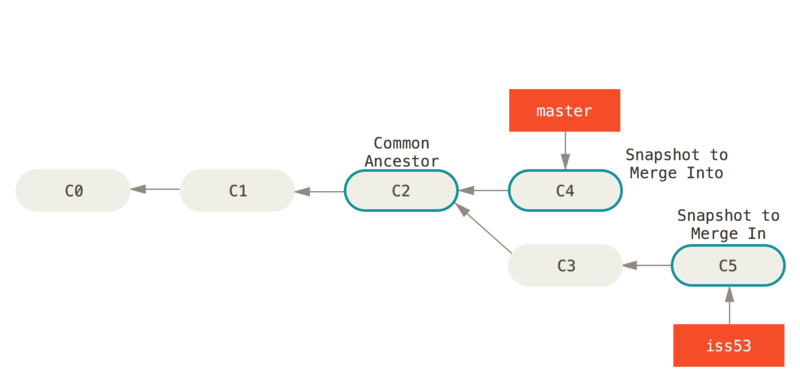

The branch being merged into, “master”, advanced. Now both the fix and the new feature are in prod!

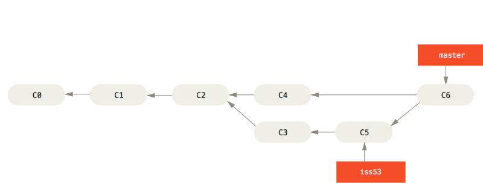

Notice in this case how Ross can be a team of people all these will still work well!

# Local Branches are Disposable

Git branches are cheap (enabled by pointer), and switching branch fast (enabled by snapshot). Why is that important?

Because one can experiment and context switch with very little consequences in a rapid manner. Like this:

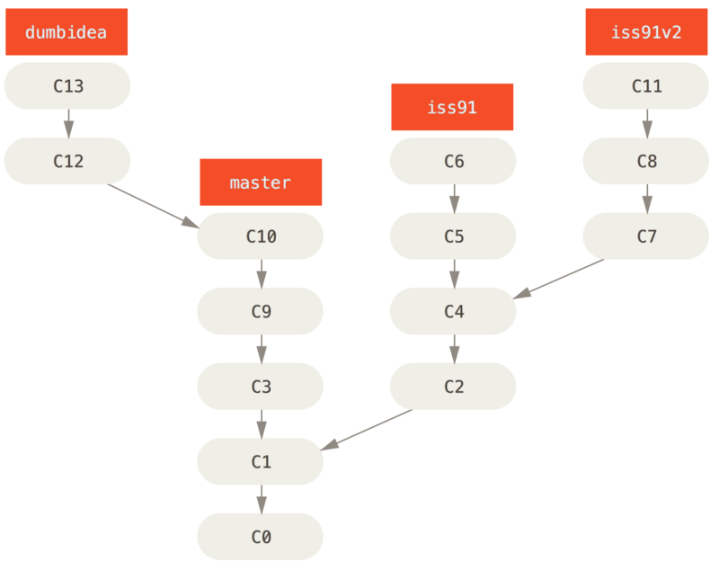

In other VCS (or not VCS) where branching by copying files and switching by adding up deltas, it could take minutes each time you diverge or switch to another branch.

Let’s say you conclude the v2 works better than v1, and the dumbidea is actually brilliant. You can delete the unused branch (throwing away C5 and C6).

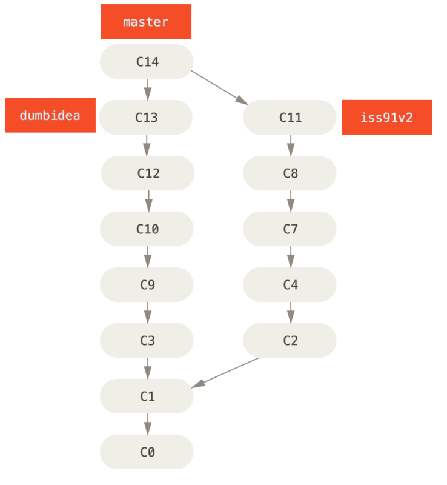

It’s important to remember these actions are **completely local**. When you’re branching and merging, everything is done offline — there is no communication with the server unless you requested it to be pushed.

**Have a lot of local branches. Dump the bad ones, polish the good ones, and share them when ready.**

# Take Away

- VCS is better than no VCS.
- A commit in Git is a contextual snapshot; chain of them forms the history.
- Git is designed around fast switching, and light-weight, disposable branching.
- Don’t be afraid to create many local branches and use them to your advantage.
- Further Reading
  - [The history of Git](https://blog.brachiosoft.com/en/posts/git/)
  - [Pro Git Book](https://git-scm.com/book/en/v2)